# AF PRS vs. AF after revascularization

**Libraries**

```r
#install.packages("/home/ivm/R/src/packrat_0.5.0.tar.gz", repos=NULL, type="source")
#install.packages("/finngen/green/tableone_0.12.0.tar.gz", repos=NULL, type="source")
#install.packages("/finngen/green/compareC_1.3.1.tar.gz", repos=NULL, type="source")

library(tidyverse)
library(survival)   # survival analysis

library(data.table) # fread() function
library(gridExtra)  # plots to grid
library(survminer)  # ggbased visualization and extra diagnostics
#library(survRM2)    # restricted mean survival times
#library(visdat)     # visualization of tibble and na's
##library(forestplot) # forestplot
library(compareC)   # compare c-index
library(kableExtra) # Pretty tables
library(tableone)   # Characteristics table

source('functions2.R')

data_path <- "data"
prs_path <- "/home/ivm/ukb-prs-others/ukb_prs_R9"
fig_path <- "figs2"
```

# 1 Data

## 1.1 Variables

**Operations**

- I9_CABG, Coronary artery bypass crafting
- I9_ANGIO, Coronary angiopasty
- I9_REVASC, I9_CABG OR I9_ANGIO

Three samples: patients *after* CABG, ANGIO and REVASC.

**For polygenic riskscores**

- I9_AF (ukb: 20002_1471), Atrial fibrillation
- I9_CHD, Major coronary heart disease event
- I9_INTRACRA, Nontraumatic intracranial haemmorrhage
- I9_MI, Myocardial infarction
- I9_STR, Stroke, excluding SAH
- K11_GIBLEEDING, GI-bleeding

## 1.2 Download & preprocess data

**Copying and preprocessing at ‘rather big machine’**

Endpoint and covariate files transfered and unzipped. Columns selected from endpoint file prior to import to r, because the original phenotype file is very large.

```r
pheno_in_path <- "/finngen/library-red/finngen_R9/phenotype_1.0/data"

columns_pheno <- fread("data/fg_pheno_cols.txt", header=F)$V1
columns_discovs <- fread("data/fg_chadsvasc_cols.txt", header=F)$V1
columns <- c(columns_pheno, columns_discovs) %>% unique()

#pheno_tmp <- vroom(str_glue("{pheno_in_path}/finngen_R9_endpoint_1.0.txt.gz"),
#                   col_select = c(FINNGENID, contains("I9_PULMEMB"), contains("I9_PHLETHROMBDVTLOW"))

pheno_tmp <- fread(str_glue("{pheno_in_path}/finngen_R9_endpoint_1.0.txt.gz")) %>%
  select(FINNGENID, all_of(columns))

fwrite(pheno_tmp, str_glue("{data_path}/R9_endpoint_selected.tsv.gz"), sep="\t")
```

**Loading and combining the data**

Downloading the data

```r
names_in <- list(I9_AF="20002_1471", I9_CHD="I9_CHD", I9_INTRACRA="I9_INTRACRA", I9_MI="I9_MI", I9_STR="I9_STR", K11_GIBLEEDING="K11_GIBLEEDING")
#names_in <- c(I9_AF="20002_1471")

#PRS scores
prs_df.f <- lapply(as.list(names(names_in)), function(prsname) {

  fread(str_glue("{prs_path}/{names_in[[prsname]]}.gwas.female.tsv.sscore")) %>%
        select(IID, SCORE1_AVG) %>%
        rename(FINNGENID = IID, !!paste(prsname, "SCORE.F", sep="_") := SCORE1_AVG )}
  ) %>%
  reduce(left_join, by = "FINNGENID")


prs_df.m <- lapply(as.list(names(names_in)), function(prsname) {

  fread(str_glue("{prs_path}/{names_in[[prsname]]}.gwas.male.tsv.sscore")) %>%
        select(IID, SCORE1_AVG) %>%
        rename(FINNGENID = IID, !!paste(prsname, "SCORE.M", sep="_") := SCORE1_AVG )}
  ) %>%
  reduce(left_join, by = "FINNGENID")


#endpoints
#As FinnGen assignes NA's to similar endpoints, we must replace NA's
phenotypes <- fread(str_glue("{data_path}/R9_endpoint_selected.tsv.gz")) %>%
  mutate_at(vars(-FINNGENID, -ends_with("_AGE"), -ends_with("_YEAR")), ~if_else(is.na(.), 0L, .))

#covariates
covs_in <- fread("/finngen/library-red/finngen_R9/analysis_covariates/R9_COV_V1.FID.txt.gz") %>%
  select(IID, SEX_IMPUTED, n_var, chip, starts_with("PC"), starts_with("IS"), batch,  ends_with("norm"), starts_with("BL"), "cohort") %>%
  rename(FINNGENID = IID) %>%
  mutate(batch2 = case_when(   #Let as create new batch variable with less levels
    IS_FINNGEN1_CHIP == 1 ~ "FINNGEN1_CHIP",
    IS_FINNGEN2_CHIP == 1 ~ "FINNGEN2_CHIP",
    TRUE ~ batch) %>% as.factor)
```

Combining the data

```r
df <- phenotypes %>%
  left_join(prs_df.f, by = "FINNGENID") %>%
  left_join(prs_df.m, by = "FINNGENID") %>%
  left_join(covs_in, by = "FINNGENID") %>%
  as_tibble() %>%
  mutate_at(c("batch2", "cohort"),as.factor)
```

**Preprocess**

Removing individuals without genetic information Also endpoint names are simplified.

```r
names_ep <- list("AF", "INTRACRA", "MI", "STR", "GIBLEEDING")

#Total number of individuals
dim(df)[1]
```

```
## [1] 392423
```

```r
#glimpse(df)
#vis_dat(sample_n(df, 10000))
df <- df %>% filter(!is.na(batch2)) %>%
  rename_at(vars(contains('I9_')), list(~str_remove(., "I9_"))) %>%
  rename_at(vars(contains('K11_')), list(~str_remove(., "K11_"))) %>%
  rename_at(vars(contains('E4_')), list(~str_remove(., "E4_"))) %>%
  rename_at(vars(contains('C_STRO')), list(~str_remove(., "C_"))) %>%
  rename_at(vars(contains('N14_')), list(~str_remove(., "N14_"))) %>%
  rename_at(vars(contains('ANGIO')), list(~str_replace(., "ANGIO", "PCI"))) %>%
  #Variable on which event is the first REVASC, CABG or REVASC
  mutate(CABG_FIRST = if_else(CABG_AGE == REVASC_AGE & CABG == 1, 1L, 0L))

#vis_dat(sample_n(df, 10000))

#Number of genotyped individuals
dim(df)[1]
```

```
## [1] 377277
```

**Set SCORE according sex**

```r
#Females and males treated separately and combined back together

df.f <-  df %>%
  filter(SEX_IMPUTED==1) %>%
  rename_at(vars(contains('SCORE.F')), list(~str_replace(., "SCORE.F", "SCORE"))) %>%
  select(-contains('SCORE.M'))

df.m <-  df %>%
  filter(SEX_IMPUTED==0) %>%
  rename_at(vars(contains('SCORE.M')), list(~str_replace(., "SCORE.M", "SCORE")))%>%
  select(-contains('SCORE.F'))

df <- NULL
```

**Categorical variables & sex**

Data is categorized and scaled separately for both genders.

```r
my_probs = c(0 , 0.25, 0.5, 0.75, 1)
my_labels =  c("Q1", "Q2", "Q3", "Q4")
my_ref = "Q1"


#my_probs = c(0,0.025,0.2,0.8,0.975,1)
#my_labels =  c("<2.5%","2.5-20%","20-80%","80-97.5%",">97.5%")

#Females

df.f <- df.f %>%
  mutate_at(vars(contains('SCORE')), list(SCALED = ~scale(.)[,1])) %>%
  rename_at(vars(contains('SCALED')), list(~str_remove(., "SCORE_"))) %>%
  mutate_at(vars(contains('SCORE')),
            list(CAT = ~cut(., breaks=quantile(., probs = my_probs),
                            labels=my_labels, include.lowest = T))) %>%
  rename_at(vars(contains('CAT')), list(~str_remove(., "SCORE_")))


df.m <- df.m %>%
  mutate_at(vars(contains('SCORE')), list(SCALED = ~scale(.)[,1])) %>%
  rename_at(vars(contains('SCALED')), list(~str_remove(., "SCORE_"))) %>%
  mutate_at(vars(contains('SCORE')),
            list(CAT = ~cut(., breaks=quantile(., probs = my_probs),
                            labels=my_labels, include.lowest = T))) %>%
  rename_at(vars(contains('CAT')), list(~str_remove(., "SCORE_")))
```

**Combining df.f + df.m**

df is generated again to include scaled and categorized variables.

```r
df <- bind_rows(df.f, df.m) %>% arrange(FINNGENID)
#vis_dat(sample_n(df, 5000))

#Number of individuals:
dim(df)[1]
```

```
## [1] 377277
```

```r
df %>% select(SEX_IMPUTED) %>% mutate_all(as.factor) %>% summary()
```

```
##  SEX_IMPUTED
##  0:166407
##  1:210870
```

## 1.3 Subset the data by operations

**Create datasets for each operations**

Lists with three datasets for each operations created

```r
names_oper <- list("REVASC", "CABG", "PCI")
names_ep <- list("AF", "INTRACRA", "MI", "STR", "GIBLEEDING")
#Datasets for each operation are filtered.


#All - needed for interactions
dfs.oper <- lapply(names_oper, function(name){
    df %>% filter(get(name) == 1)
  }) %>% setNames(names_oper)

lapply(names_oper, function(oper){
  dfs.oper[[oper]] %>%
    summarise(oper=oper, n=n(), females=sum(SEX_IMPUTED), fem_p = mean(SEX_IMPUTED)*100,
              males=n()-sum(SEX_IMPUTED))
}) %>%
  reduce(bind_rows)
```

```
## # A tibble: 3 × 5
##   oper       n females fem_p males
##   <chr>  <int>   <int> <dbl> <int>
## 1 REVASC 23139    5561  24.0 17578
## 2 CABG   10938    1807  16.5  9131
## 3 PCI    14723    4195  28.5 10528
```

**Calculate preoperative values for variables**

Also CHA<sub>2</sub>DS<sub>2</sub>-VASc score is calculated.

```r
dfs.oper <- lapply(names_oper, function(oper){

  oper_age <- str_glue("{oper}_AGE")
  dfs.oper[[oper]] %>%
  mutate(MIPAD = if_else(MI|PAD, 1, 0)) %>%
  mutate(HYPERCHOL_WIDE = if_else(HYPERCHOL|RX_STATIN, 1, 0)) %>%
  rowwise()%>%
    mutate(MIPAD_AGE = min(MI_AGE, PAD_AGE)) %>%
    mutate(HYPERCHOL_WIDE_AGE = min(HYPERCHOL_AGE, RX_STATIN_AGE)) %>%
  ungroup() %>%
  mutate(oper_AGE_65 = if_else(get(oper_age) >= 65, 1, 0),
         oper_AGE_75 = if_else(get(oper_age) >= 75, 1, 0),
         oper_AGE_65_75 = if_else((oper_AGE_65 == 1 & oper_AGE_75 == 0),1, 0),
         preop_HEARTFAIL = if_else(HEARTFAIL_AGE < get(oper_age), 1, 0),
         preop_HYPTENS = if_else(HYPTENS_AGE < get(oper_age), 1, 0),
         preop_DIABETES = if_else(DIABETES_AGE < get(oper_age), 1, 0),
         preop_STROKE = if_else(STROKE_AGE < get(oper_age), 1, 0),
         preop_MIPAD = if_else(MIPAD_AGE < get(oper_age), 1, 0),
         preop_VHD = if_else(VHD_AGE < get(oper_age), 1, 0),
         preop_OBESITY = if_else(OBESITY_AGE < get(oper_age), 1, 0),
         preop_HYPERCHOL_WIDE = if_else(HYPERCHOL_WIDE_AGE < get(oper_age), 1, 0),
         preop_CHRONKIDNEYDIS =  if_else(CHRONKIDNEYDIS_AGE < get(oper_age), 1, 0),
         CVSC = preop_HEARTFAIL + preop_HYPTENS + oper_AGE_75 + preop_DIABETES +
           2*preop_STROKE + preop_MIPAD + oper_AGE_65 + SEX_IMPUTED,
         CVSC_SCALED = scale(CVSC)[,1])

}) %>% setNames(names_oper)
```

**Prevalent cases removed and simplified**

```r
#Datasets for each operation are filtered and added to list

covs <- c("batch2", "BL_YEAR","PC1", "PC2", "PC3", "PC4", "PC5", "PC6", "PC7", "PC8","PC9", "PC10")
discovs <- c( "preop_HYPTENS", "preop_OBESITY", "preop_DIABETES",  "preop_HYPERCHOL_WIDE", "preop_CHRONKIDNEYDIS")

#Lists of dataframes for each operations and each endpoint of interest
#PREVALENT ARE REMOVED

dfs <- lapply(names_oper, function(oper){
  my_create_sub_dfs(oper, dfs.oper, names_ep, c(covs, "SEX_IMPUTED", "CABG_FIRST","CABG", "PCI", discovs)) }) %>%
  setNames(names_oper)

#n for REVASCS

lapply(dfs$REVASC, dim)
```

```
## $AF
## [1] 20419    43
##
## $INTRACRA
## [1] 22786    39
##
## $MI
## [1] 12907    44
##
## $STR
## [1] 21683    42
##
## $GIBLEEDING
## [1] 22670    39
```

**Divided to two dataset by sex**

```r
#Females
dfs.f <-
  lapply(names_oper, function(oper){
    lapply(names_ep, function(ep){
      dfs[[oper]][[ep]] %>% filter(SEX_IMPUTED==1)
    }) %>% setNames(names_ep)
  }) %>% setNames(names_oper)

#Males
dfs.m <-
  lapply(names_oper, function(oper){
    lapply(names_ep, function(ep){
      dfs[[oper]][[ep]] %>% filter(SEX_IMPUTED==0)
  }) %>% setNames(names_ep)
}) %>% setNames(names_oper)
```

**Mean followup time**

Women

```r
lapply(names_oper, function(oper){
  dfs.f[[oper]][["AF"]] %>%
    summarise(mean = mean(AGE_DIFF), median = median(AGE_DIFF))
})%>% setNames(names_oper)
```

```
## $REVASC
## # A tibble: 1 × 2
##    mean median
##   <dbl>  <dbl>
## 1  8.84   7.71
##
## $CABG
## # A tibble: 1 × 2
##    mean median
##   <dbl>  <dbl>
## 1  10.1   9.27
##
## $PCI
## # A tibble: 1 × 2
##    mean median
##   <dbl>  <dbl>
## 1  8.36   7.25
```

Men

```r
lapply(names_oper, function(oper){
  dfs.m[[oper]][["AF"]] %>%
    summarise(mean = mean(AGE_DIFF), median = median(AGE_DIFF))
})%>% setNames(names_oper)
```

```
## $REVASC
## # A tibble: 1 × 2
##    mean median
##   <dbl>  <dbl>
## 1  10.3   9.46
##
## $CABG
## # A tibble: 1 × 2
##    mean median
##   <dbl>  <dbl>
## 1  10.7   9.78
##
## $PCI
## # A tibble: 1 × 2
##    mean median
##   <dbl>  <dbl>
## 1  9.55   8.83
```

**Correlation between clinical and AF genetic score:**

All

```r
#Spearman
cor(dfs$REVASC$AF$CVSC_SCALED, dfs$REVASC$AF$AF_SCALED, method = "spearman")
```

```
## [1] -0.00812338
```

Women

```r
#Spearman
cor(dfs.f$REVASC$AF$CVSC_SCALED, dfs.f$REVASC$AF$AF_SCALED, method = "spearman")
```

```
## [1] -0.02104042
```

Men

```r
cor(dfs.m$REVASC$AF$CVSC_SCALED, dfs.m$REVASC$AF$AF_SCALED, method = "spearman")
```

```
## [1] -0.01177685
```

## 1.4 Characteristics tables for each operations

Here all characteristics are at the age of operation.

```r
myVars <-  c("AGE_DIFF", "REVASC_AGE", "CABG_FIRST", discovs)
catVars <- c("CABG_FIRST", discovs)
chr_rownames <- c("Follow up, years (SD)", "Age, years (SD)", "CABG first, n (%)")


#AF
strata <- "AF"
chr.af.f <- CreateTableOne(vars=myVars, data=dfs.f[["REVASC"]][[strata]], factorVars = catVars, strata=strata, test=F)
chr.af.m <- CreateTableOne(vars=myVars, data=dfs.m[["REVASC"]][[strata]], factorVars = catVars, strata=strata, test=F)
chr.af.all <- CreateTableOne(vars=myVars, data=dfs[["REVASC"]][[strata]], factorVars = catVars, test=F)

#IC bleeding
strata <- "INTRACRA"
chr.ich.f <- CreateTableOne(vars=myVars, data=dfs.f[["REVASC"]][[strata]], factorVars = catVars, strata=strata, test=F)
chr.ich.m <- CreateTableOne(vars=myVars, data=dfs.m[["REVASC"]][[strata]], factorVars = catVars, strata=strata, test=F)
chr.ich.all <- CreateTableOne(vars=myVars, data=dfs[["REVASC"]][[strata]], factorVars = catVars, test=F)
```

**Women**

```r
chr.af.f
```

```
##                               Stratified by AF
##                                0             1
##   n                             3823          1172
##   AGE_DIFF (mean (SD))          9.14 (6.49)   7.86 (6.49)
##   REVASC_AGE (mean (SD))       64.43 (11.89) 67.95 (9.53)
##   CABG_FIRST = 1 (%)             916 (24.0)    487 (41.6)
##   preop_HYPTENS = 1 (%)         1712 (44.8)    642 (54.8)
##   preop_OBESITY = 1 (%)          159 ( 4.2)     42 ( 3.6)
##   preop_DIABETES = 1 (%)         980 (25.6)    282 (24.1)
##   preop_HYPERCHOL_WIDE = 1 (%)  2174 (56.9)    725 (61.9)
##   preop_CHRONKIDNEYDIS = 1 (%)    59 ( 1.5)     13 ( 1.1)
```

```r
chr.ich.f
```

```
##                               Stratified by INTRACRA
##                                0               1
##   n                            " 5379"         "   94"
##   AGE_DIFF (mean (SD))         " 9.84 (6.72)"  " 9.38 (6.03)"
##   REVASC_AGE (mean (SD))       "66.02 (11.51)" "66.86 (9.43)"
##   CABG_FIRST = 1 (%)           " 1501 (27.9) " "   42 (44.7) "
##   preop_HYPTENS = 1 (%)        " 2633 (48.9) " "   49 (52.1) "
##   preop_OBESITY = 1 (%)        "  223 ( 4.1) " "-"
##   preop_DIABETES = 1 (%)       " 1374 (25.5) " "   25 (26.6) "
##   preop_HYPERCHOL_WIDE = 1 (%) " 3174 (59.0) " "   46 (48.9) "
##   preop_CHRONKIDNEYDIS = 1 (%) "   79 ( 1.5) " "-"
```

**Men**

```r
chr.af.m
```

```
##                               Stratified by AF
##                                0             1
##   n                            10881          4543
##   AGE_DIFF (mean (SD))         11.08 (7.13)   8.47 (7.18)
##   REVASC_AGE (mean (SD))       63.01 (10.36) 63.97 (9.45)
##   CABG_FIRST = 1 (%)            4588 (42.2)   2609 (57.4)
##   preop_HYPTENS = 1 (%)         4117 (37.8)   1995 (43.9)
##   preop_OBESITY = 1 (%)          241 ( 2.2)    112 ( 2.5)
##   preop_DIABETES = 1 (%)        2380 (21.9)    904 (19.9)
##   preop_HYPERCHOL_WIDE = 1 (%)  6093 (56.0)   2354 (51.8)
##   preop_CHRONKIDNEYDIS = 1 (%)   176 ( 1.6)     50 ( 1.1)
```

```r
chr.ich.m
```

```
##                               Stratified by INTRACRA
##                                0             1
##   n                            16958           355
##   AGE_DIFF (mean (SD))         11.68 (7.38)   9.52 (7.15)
##   REVASC_AGE (mean (SD))       64.05 (10.21) 64.51 (9.56)
##   CABG_FIRST = 1 (%)            7812 (46.1)    207 (58.3)
##   preop_HYPTENS = 1 (%)         7024 (41.4)    159 (44.8)
##   preop_OBESITY = 1 (%)          450 ( 2.7)      7 ( 2.0)
##   preop_DIABETES = 1 (%)        3756 (22.1)     76 (21.4)
##   preop_HYPERCHOL_WIDE = 1 (%)  9525 (56.2)    188 (53.0)
##   preop_CHRONKIDNEYDIS = 1 (%)   272 ( 1.6)      7 ( 2.0)
```

**All**

```r
chr.af.all
```

```
##
##                                Overall
##   n                            20419
##   AGE_DIFF (mean (SD))          9.95 (7.10)
##   REVASC_AGE (mean (SD))       63.77 (10.49)
##   CABG_FIRST = 1 (%)            8600 (42.1)
##   preop_HYPTENS = 1 (%)         8466 (41.5)
##   preop_OBESITY = 1 (%)          554 ( 2.7)
##   preop_DIABETES = 1 (%)        4546 (22.3)
##   preop_HYPERCHOL_WIDE = 1 (%) 11346 (55.6)
##   preop_CHRONKIDNEYDIS = 1 (%)   298 ( 1.5)
```

```r
chr.ich.all
```

```
##
##                                Overall
##   n                            22786
##   AGE_DIFF (mean (SD))         11.20 (7.26)
##   REVASC_AGE (mean (SD))       64.53 (10.55)
##   CABG_FIRST = 1 (%)            9562 (42.0)
##   preop_HYPTENS = 1 (%)         9865 (43.3)
##   preop_OBESITY = 1 (%)          681 ( 3.0)
##   preop_DIABETES = 1 (%)        5231 (23.0)
##   preop_HYPERCHOL_WIDE = 1 (%) 12933 (56.8)
##   preop_CHRONKIDNEYDIS = 1 (%)   359 ( 1.6)
```

## 1.5 Linearized rate

**Linearized rate**

*Women*

```r
linrate.f.l <- lapply(names_ep, function(ep){
  dfs.f[["REVASC"]][[ep]] %>%
    group_by(get(str_glue("{ep}_CAT"))) %>%
    summarise(lin_rate=(sum(get(ep))/sum(FU_END_AGE-REVASC_AGE))*100, n=n(), nevent=sum(get(ep))) %>%
    rename(PRS=`get(str_glue("{ep}_CAT"))`)
})%>%setNames(names_ep)


linrate.f.l
```

```
## $AF
## # A tibble: 4 × 4
##   PRS   lin_rate     n nevent
##   <fct>    <dbl> <int>  <int>
## 1 Q1        2.12  1279    268
## 2 Q2        2.27  1241    283
## 3 Q3        2.55  1220    317
## 4 Q4        2.34  1255    304
##
## $INTRACRA
## # A tibble: 4 × 4
##   PRS   lin_rate     n nevent
##   <fct>    <dbl> <int>  <int>
## 1 Q1       0.142  1359     19
## 2 Q2       0.168  1338     22
## 3 Q3       0.127  1341     17
## 4 Q4       0.255  1435     36
##
## $MI
## # A tibble: 4 × 4
##   PRS   lin_rate     n nevent
##   <fct>    <dbl> <int>  <int>
## 1 Q1        1.53   752    109
## 2 Q2        1.39   810    106
## 3 Q3        1.64   872    140
## 4 Q4        1.56  1012    156
##
## $STR
## # A tibble: 4 × 4
##   PRS   lin_rate     n nevent
##   <fct>    <dbl> <int>  <int>
## 1 Q1       0.953  1224    118
## 2 Q2       1.10   1300    142
## 3 Q3       0.961  1350    127
## 4 Q4       1.12   1343    152
##
## $GIBLEEDING
## # A tibble: 4 × 4
##   PRS   lin_rate     n nevent
##   <fct>    <dbl> <int>  <int>
## 1 Q1       0.333  1376     46
## 2 Q2       0.457  1336     60
## 3 Q3       0.515  1361     69
## 4 Q4       0.399  1383     55
```

*Men*

```r
linrate.m.l <- lapply(names_ep, function(ep){
  dfs.m[["REVASC"]][[ep]] %>%
    group_by(get(str_glue("{ep}_CAT"))) %>%
    summarise(lin_rate=(sum(get(ep))/sum(FU_END_AGE-REVASC_AGE))*100, n=n(), nevent=sum(get(ep)))  %>%
    rename(PRS=`get(str_glue("{ep}_CAT"))`)
})%>%setNames(names_ep)


linrate.m.l
```

```
## $AF
## # A tibble: 4 × 4
##   PRS   lin_rate     n nevent
##   <fct>    <dbl> <int>  <int>
## 1 Q1        2.19  3980   1049
## 2 Q2        2.30  4068   1117
## 3 Q3        2.46  3726   1136
## 4 Q4        2.76  3650   1241
##
## $INTRACRA
## # A tibble: 4 × 4
##   PRS   lin_rate     n nevent
##   <fct>    <dbl> <int>  <int>
## 1 Q1       0.183  4236     91
## 2 Q2       0.183  4312     92
## 3 Q3       0.183  4319     93
## 4 Q4       0.151  4446     79
##
## $MI
## # A tibble: 4 × 4
##   PRS   lin_rate     n nevent
##   <fct>    <dbl> <int>  <int>
## 1 Q1        1.60  1833    327
## 2 Q2        1.51  2244    401
## 3 Q3        1.55  2511    455
## 4 Q4        1.58  2873    561
##
## $STR
## # A tibble: 4 × 4
##   PRS   lin_rate     n nevent
##   <fct>    <dbl> <int>  <int>
## 1 Q1        1.00  4018    481
## 2 Q2        1.08  4090    527
## 3 Q3        1.08  4118    530
## 4 Q4        1.11  4240    558
##
## $GIBLEEDING
## # A tibble: 4 × 4
##   PRS   lin_rate     n nevent
##   <fct>    <dbl> <int>  <int>
## 1 Q1       0.406  4216    202
## 2 Q2       0.407  4322    207
## 3 Q3       0.436  4359    223
## 4 Q4       0.525  4317    268
```

# 2 Survival analysis

**KM plots for each endpoint**

**Model by survfit**

```r
names_oper=list("REVASC")

kms.f <-
  lapply(names_oper, function(oper){
    lapply(names_ep, function(ep){
      survfit(Surv(AGE_DIFF, get(ep)) ~ get(str_glue("{ep}_CAT")), data=dfs.f[[oper]][[ep]])
    }) %>% setNames(names_ep)
  }) %>% setNames(names_oper)


kms.m <-
  lapply(names_oper, function(oper){
    lapply(names_ep, function(ep){
      survfit(Surv(AGE_DIFF, get(ep)) ~ get(str_glue("{ep}_CAT")), data=dfs.m[[oper]][[ep]])
    }) %>% setNames(names_ep)
  }) %>% setNames(names_oper)
```

**The plot**

```
## REVASC-AF
## REVASC-INTRACRA
## REVASC-MI
## REVASC-STR
## REVASC-GIBLEEDING
```

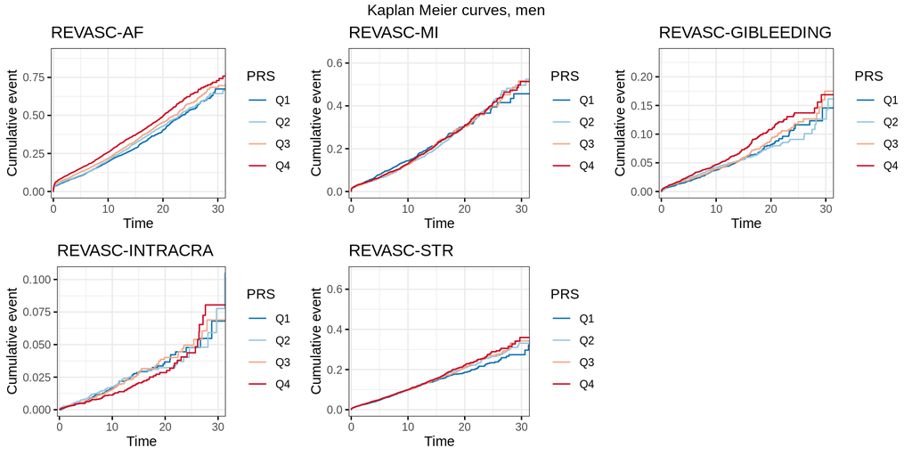

```r
for(oper in unlist(names_oper)) {
  ep=names_ep[[1]]   #Tämän alustuksen tarve on kyllä ihme juttu. Suoritus kaatuu ilman sitä.

  plot_list <- lapply(names_ep, function(ep){
    #print(str_glue("{oper}-{ep}"))
    my_ggkmplot(kms.f[[oper]][[ep]], str_glue("{oper}-{ep}"), my_labels, nr_col=4)
  })
  plots <- arrange_ggsurvplots(plot_list, nrow = 2, ncol = 3, title = "Kaplan Meier curves, women", print=F)
  ggsave(file = str_glue("{fig_path}/km.prs.{oper}.f.png"), plot = plots, height = 6, width = 12, dpi = 200)
}


for(oper in unlist(names_oper)) {
  ep=names_ep[[1]]   #Tämän alustuksen tarve on kyllä ihme juttu. Suoritus kaatuu ilman sitä.

  plot_list <- lapply(names_ep, function(ep){
    print(str_glue("{oper}-{ep}"))
    my_ggkmplot(kms.m[[oper]][[ep]], str_glue("{oper}-{ep}"), my_labels, nr_col=4)
  })
  plots <- arrange_ggsurvplots(plot_list, nrow = 2, ncol = 3, title = "Kaplan Meier curves, men", print=T)
  ggsave(file = str_glue("{fig_path}/km.prs.{oper}.m.png"), plot = plots, height = 6, width = 12, dpi = 200)
}
```

**Females**

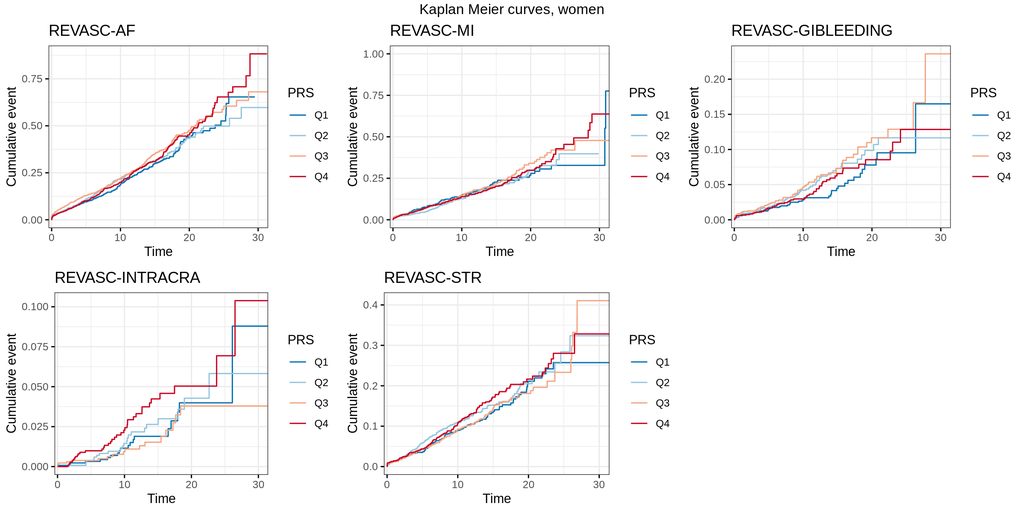

KM curves

**Males**

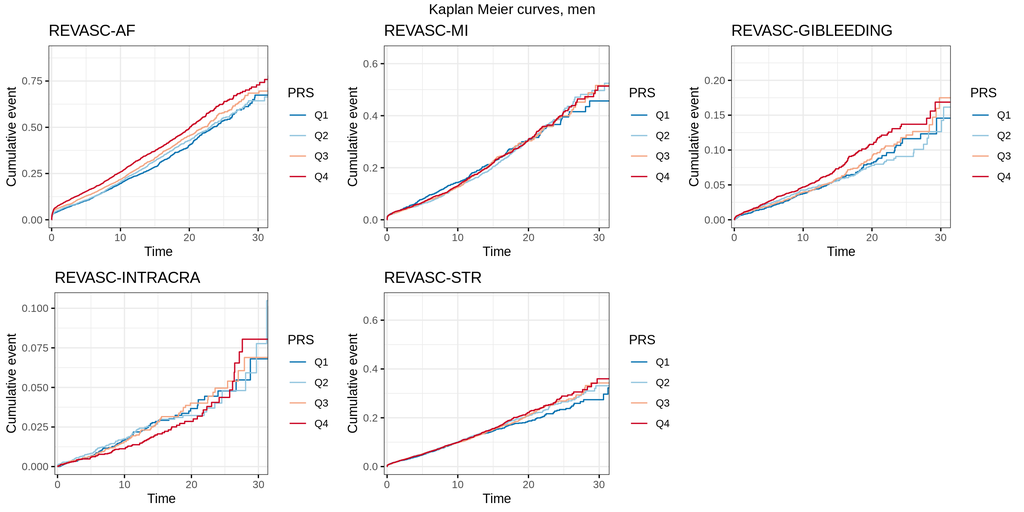

KM curves

**cloglog curves for each endpoint**

```
## REVASC-AF
## REVASC-INTRACRA
## REVASC-MI
## REVASC-STR
## REVASC-GIBLEEDING
```

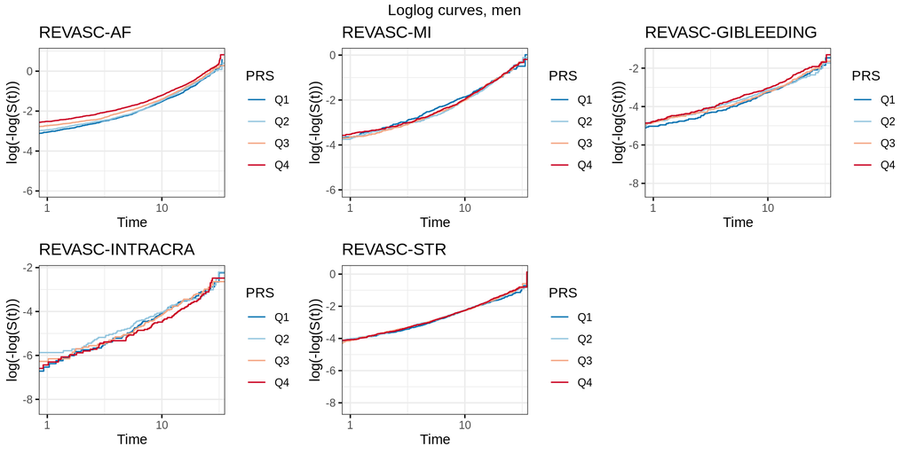

```r
for(oper in unlist(names_oper)) {
  ep=names_ep[[1]]   #Tämän alustuksen tarve on kyllä ihme juttu. Suoritus kaatuu ilman sitä.

  plot_list <- lapply(names_ep, function(ep){
    #print(str_glue("{oper}-{ep}"))
    my_ggkmplot(kms.f[[oper]][[ep]], str_glue("{oper}-{ep}"), my_labels, nr_col=4, fun="cloglog", xlim=c(1,30))
  })
  plots <- arrange_ggsurvplots(plot_list, nrow = 2, ncol = 3, title = "Loglog curves, women", print=F)
  ggsave(file = str_glue("{fig_path}/log.prs.{oper}.f.png"), plot = plots, height = 6, width = 12, dpi = 200)
}


for(oper in unlist(names_oper)) {
  ep=names_ep[[1]]   #Tämän alustuksen tarve on kyllä ihme juttu. Suoritus kaatuu ilman sitä.

  plot_list <- lapply(names_ep, function(ep){
    print(str_glue("{oper}-{ep}"))
    my_ggkmplot(kms.m[[oper]][[ep]], str_glue("{oper}-{ep}"), my_labels, nr_col=4, fun="cloglog", xlim=c(1,30))
  })
  plots <- arrange_ggsurvplots(plot_list, nrow = 2, ncol = 3, title = "Loglog curves, men", print=T)
  ggsave(file = str_glue("{fig_path}/log.prs.{oper}.m.png"), plot = plots, height = 6, width = 12, dpi = 200)
}
```

**Females**

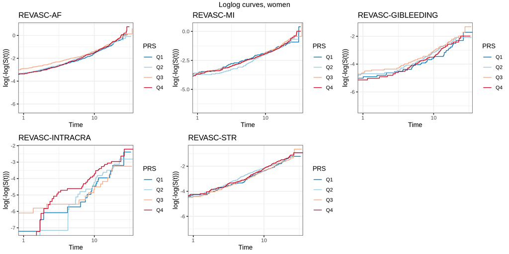

cloglog

**Males**

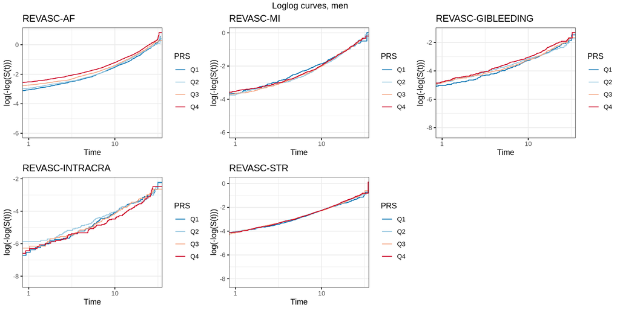

cloglog

## 2.1 Cox model: covariate adjusted, continuous score

**Running models**

```r
covs_f<- paste(c(covs,discovs), collapse = " + ")

names_oper=list("REVASC", "CABG", "PCI")

cxs.cs.f <-
  lapply(names_oper, function(oper){
    lapply(names_ep, function(ep){
      my_formula <- str_glue("Surv(AGE_DIFF, {ep}) ~ {ep}_SCALED + {oper}_AGE + CABG_FIRST + {covs_f}")
      coxph(as.formula(my_formula), data=dfs.f[[oper]][[ep]])
    }) %>% setNames(names_ep)
  }) %>% setNames(names_oper)

cxs.cs.m <-
  lapply(names_oper, function(oper){
    lapply(names_ep, function(ep){
      my_formula <- str_glue("Surv(AGE_DIFF, {ep}) ~ {ep}_SCALED + {oper}_AGE + CABG_FIRST + {covs_f}")
      coxph(as.formula(my_formula), data=dfs.m[[oper]][[ep]])
    }) %>% setNames(names_ep)
  }) %>% setNames(names_oper)


cxs.cs.i <-
  lapply(names_oper, function(oper){
    lapply(names_ep, function(ep){
      my_formula <- str_glue("Surv(AGE_DIFF, {ep}) ~ {ep}_SCALED*SEX_IMPUTED + {oper}_AGE + CABG_FIRST + {covs_f}")
      coxph(as.formula(my_formula), data=dfs[[oper]][[ep]])
    }) %>% setNames(names_ep)
  }) %>% setNames(names_oper)
```

**Table: Hazard rations**

```r
dflist <- list(f=dfs.f, m=dfs.m, b=dfs)
cxlist <- list(f=cxs.cs.f, m=cxs.cs.m, i=cxs.cs.i)

hr_table   <- my_cxlist_to_hrtable_list_sex(list("REVASC", "CABG", "PCI"),   names_ep, dflist, cxlist)


hr_table %>%
  knitr::kable() %>%
  kable_classic(full_width=F, position="left") %>%
  pack_rows("REVASC",1, 5) %>%
  pack_rows("CABG",6, 10) %>%
  pack_rows("PCI",11, 15) %>%
  row_spec(0,bold=T) %>%
  add_header_above(c(" "=1, "Female"=4, "Male"=4, "Interaction"=2), bold=T)
```

|  | Female Cases/Controls | Female HR (95% CI) | Female P-value | Female FDR | Male Cases/Controls | Male HR (95% CI) | Male P-value | Male FDR | Interaction P-value | Interaction FDR |
| --- | --- | --- | --- | --- | --- | --- | --- | --- | --- | --- |
| **REVASC** |  |  |  |  |  |  |  |  |  |  |
| AF | 1172/3823 | 1.06 (1-1.12) | 0.054 | 0.27 | 4543/10881 | 1.16 (1.12-1.19) | 7.6e-22 | 1.1e-20 | 0.0064 | 0.057 |
| INTRACRA | 94/5379 | 1.32 (1.07-1.61) | 0.0082 | 0.12 | 355/16958 | 0.96 (0.86-1.07) | 0.45 | 1 | 0.0076 | 0.057 |
| MI | 511/2935 | 1.06 (0.97-1.16) | 0.18 | 0.69 | 1744/7717 | 1.02 (0.98-1.08) | 0.34 | 1 | 0.57 | 1 |
| STR | 539/4678 | 1.09 (1-1.19) | 0.047 | 0.27 | 2096/14370 | 1.04 (1-1.09) | 0.065 | 0.33 | 0.36 | 1 |
| GIBLEEDING | 230/5226 | 1.08 (0.95-1.23) | 0.25 | 0.75 | 900/16314 | 1.13 (1.06-1.21) | 0.00022 | 0.0016 | 0.52 | 1 |
| **CABG** |  |  |  |  |  |  |  |  |  |  |
| AF | 546/1057 | 1.05 (0.96-1.14) | 0.3 | 0.89 | 2876/5150 | 1.14 (1.1-1.18) | 6.3e-12 | 9.5e-11 | 0.11 | 0.55 |
| INTRACRA | 49/1733 | 1.32 (0.99-1.76) | 0.057 | 0.43 | 219/8787 | 0.95 (0.83-1.08) | 0.44 | 1 | 0.067 | 0.55 |
| MI | 227/949 | 1.14 (1-1.3) | 0.053 | 0.43 | 1032/4353 | 1.02 (0.96-1.08) | 0.57 | 1 | 0.089 | 0.55 |
| STR | 250/1454 | 1.09 (0.96-1.24) | 0.21 | 0.77 | 1325/7229 | 1.06 (1.01-1.12) | 0.032 | 0.16 | 0.85 | 1 |
| GIBLEEDING | 92/1688 | 1.14 (0.93-1.4) | 0.21 | 0.77 | 514/8456 | 1.12 (1.03-1.23) | 0.01 | 0.075 | 0.79 | 1 |
| **PCI** |  |  |  |  |  |  |  |  |  |  |
| AF | 738/3002 | 1.05 (0.98-1.13) | 0.15 | 1 | 2228/6819 | 1.19 (1.14-1.24) | 3e-15 | 4.5e-14 | 0.0029 | 0.044 |
| INTRACRA | 56/4064 | 1.31 (1-1.71) | 0.051 | 0.76 | 171/10183 | 0.99 (0.85-1.15) | 0.89 | 1 | 0.069 | 0.52 |
| MI | 335/2141 | 1.05 (0.94-1.17) | 0.37 | 1 | 901/4019 | 1.02 (0.95-1.09) | 0.54 | 1 | 0.95 | 1 |
| STR | 346/3578 | 1.06 (0.95-1.19) | 0.26 | 1 | 1006/8798 | 1 (0.94-1.06) | 0.99 | 1 | 0.29 | 1 |
| GIBLEEDING | 160/3949 | 1.03 (0.88-1.2) | 0.75 | 1 | 500/9769 | 1.15 (1.06-1.26) | 0.0016 | 0.012 | 0.18 | 0.92 |

**All coefficients**

```r
lapply(cxs.cs.f, print)
lapply(cxs.cs.m, print)
```

[output not shown]

**All coefficients**

```r
lapply(cxs.cs.m, print)
```

```
## $AF
## Call:
## coxph(formula = as.formula(my_formula), data = dfs.m[[oper]][[ep]])
##
##                                                         coef  exp(coef)
## AF_SCALED                                           0.145718   1.156870
## REVASC_AGE                                          0.051699   1.053059
## CABG_FIRST                                          0.229621   1.258122
## batch2DS10_FINRISK_Palotie_norm                    -0.872055   0.418091
## batch2DS11_FINRISK_PredictCVD_COROGENE_Tarto_norm  -0.944636   0.388821
## batch2DS12_FINRISK_Summit_norm                     -0.661552   0.516050
## batch2DS13_FINRISK_Bf_norm                         -0.624539   0.535508
## batch2DS14_GENERISK_norm                           -1.208551   0.298630
## batch2DS15_H2000_Broad_norm                        -0.820578   0.440177
## batch2DS16_H2000_Fimm_norm                         -0.163241   0.849387
## batch2DS17_H2000_Genmets_norm                      -0.706249   0.493492
## batch2DS18_MIGRAINE_1_norm                         -0.811857   0.444033
## batch2DS19_MIGRAINE_2_norm                         -1.225646   0.293568
## batch2DS2_BOTNIA_T2dgo_norm                        -0.962733   0.381848
## batch2DS20_SUPER_1_norm                            -1.464429   0.231210
## batch2DS21_SUPER_2_norm                            -0.085575   0.917984
## batch2DS22_TWINS_1_norm                            -1.464828   0.231118
## batch2DS23_TWINS_2_norm                            -1.082402   0.338781
## batch2DS24_SUPER_3_norm                            -1.246486   0.287513
## batch2DS25_BOTNIA_Regeneron_norm                   -0.853090   0.426096
## batch2DS26_DIREVA_norm                             -1.106267   0.330792
## batch2DS3_COROGENE_Sanger_norm                     -0.747288   0.473649
## batch2DS4_FINRISK_Corogene_norm                    -0.934665   0.392718
## batch2DS5_FINRISK_Engage_norm                      -0.957143   0.383988
## batch2DS6_FINRISK_FR02_Broad_norm                  -0.867763   0.419890
## batch2DS7_FINRISK_FR12_norm                        -0.970271   0.378980
## batch2DS8_FINRISK_Finpcga_norm                     -0.931844   0.393827
## batch2DS9_FINRISK_Mrpred_norm                      -0.584884   0.557171
## batch2FINNGEN1_CHIP                                -0.799870   0.449387
## batch2FINNGEN2_CHIP                                -0.804919   0.447124
## BL_YEAR                                             0.001636   1.001637
## PC1                                                 0.111868   1.118366
## PC2                                                -3.047091   0.047497
## PC3                                                 6.660192 780.700874
## PC4                                                -2.448760   0.086401
```

[output cut: 1474 more lines]

```
## PC4                                                5.323e+00 -0.248  0.80395
## PC5                                                5.729e+00  0.705  0.48061
## PC6                                                5.901e+00 -0.176  0.86014
## PC7                                                6.723e+00  1.375  0.16928
## PC8                                                6.875e+00  1.207  0.22746
## PC9                                                7.662e+00  0.394  0.69348
## PC10                                               7.961e+00 -0.690  0.48998
## preop_HYPTENS                                      9.483e-02  4.031 5.54e-05
## preop_OBESITY                                      2.540e-01  1.403  0.16060
## preop_DIABETES                                     1.139e-01  0.913  0.36109
## preop_HYPERCHOL_WIDE                               9.690e-02 -0.929  0.35294
## preop_CHRONKIDNEYDIS                               3.109e-01  1.839  0.06589
##
## Likelihood ratio test=153.7  on 46 df, p=1.581e-13
## n= 10269, number of events= 500
```

```
## $REVASC
## $REVASC$AF
## Call:
## coxph(formula = as.formula(my_formula), data = dfs.m[[oper]][[ep]])
##
##                                                         coef  exp(coef)
## AF_SCALED                                           0.145718   1.156870
## REVASC_AGE                                          0.051699   1.053059
## CABG_FIRST                                          0.229621   1.258122
## batch2DS10_FINRISK_Palotie_norm                    -0.872055   0.418091
## batch2DS11_FINRISK_PredictCVD_COROGENE_Tarto_norm  -0.944636   0.388821
## batch2DS12_FINRISK_Summit_norm                     -0.661552   0.516050
## batch2DS13_FINRISK_Bf_norm                         -0.624539   0.535508
## batch2DS14_GENERISK_norm                           -1.208551   0.298630
## batch2DS15_H2000_Broad_norm                        -0.820578   0.440177
## batch2DS16_H2000_Fimm_norm                         -0.163241   0.849387
## batch2DS17_H2000_Genmets_norm                      -0.706249   0.493492
## batch2DS18_MIGRAINE_1_norm                         -0.811857   0.444033
## batch2DS19_MIGRAINE_2_norm                         -1.225646   0.293568
## batch2DS2_BOTNIA_T2dgo_norm                        -0.962733   0.381848
## batch2DS20_SUPER_1_norm                            -1.464429   0.231210
## batch2DS21_SUPER_2_norm                            -0.085575   0.917984
## batch2DS22_TWINS_1_norm                            -1.464828   0.231118
## batch2DS23_TWINS_2_norm                            -1.082402   0.338781
## batch2DS24_SUPER_3_norm                            -1.246486   0.287513
## batch2DS25_BOTNIA_Regeneron_norm                   -0.853090   0.426096
## batch2DS26_DIREVA_norm                             -1.106267   0.330792
## batch2DS3_COROGENE_Sanger_norm                     -0.747288   0.473649
## batch2DS4_FINRISK_Corogene_norm                    -0.934665   0.392718
## batch2DS5_FINRISK_Engage_norm                      -0.957143   0.383988
## batch2DS6_FINRISK_FR02_Broad_norm                  -0.867763   0.419890
## batch2DS7_FINRISK_FR12_norm                        -0.970271   0.378980
## batch2DS8_FINRISK_Finpcga_norm                     -0.931844   0.393827
## batch2DS9_FINRISK_Mrpred_norm                      -0.584884   0.557171
## batch2FINNGEN1_CHIP                                -0.799870   0.449387
## batch2FINNGEN2_CHIP                                -0.804919   0.447124
## BL_YEAR                                             0.001636   1.001637
## PC1                                                 0.111868   1.118366
## PC2                                                -3.047091   0.047497
## PC3                                                 6.660192 780.700874
```

[output cut: 1479 more lines]

```
## PC4                                                5.323e+00 -0.248  0.80395
## PC5                                                5.729e+00  0.705  0.48061
## PC6                                                5.901e+00 -0.176  0.86014
## PC7                                                6.723e+00  1.375  0.16928
## PC8                                                6.875e+00  1.207  0.22746
## PC9                                                7.662e+00  0.394  0.69348
## PC10                                               7.961e+00 -0.690  0.48998
## preop_HYPTENS                                      9.483e-02  4.031 5.54e-05
## preop_OBESITY                                      2.540e-01  1.403  0.16060
## preop_DIABETES                                     1.139e-01  0.913  0.36109
## preop_HYPERCHOL_WIDE                               9.690e-02 -0.929  0.35294
## preop_CHRONKIDNEYDIS                               3.109e-01  1.839  0.06589
##
## Likelihood ratio test=153.7  on 46 df, p=1.581e-13
## n= 10269, number of events= 500
```

```r
lapply(cxs.cs.f, print)
```

```
## $AF
## Call:
## coxph(formula = as.formula(my_formula), data = dfs.f[[oper]][[ep]])
##
##                                                         coef  exp(coef)
## AF_SCALED                                          5.607e-02  1.058e+00
## REVASC_AGE                                         6.432e-02  1.066e+00
## CABG_FIRST                                         3.334e-01  1.396e+00
## batch2DS10_FINRISK_Palotie_norm                    1.621e+00  5.056e+00
## batch2DS11_FINRISK_PredictCVD_COROGENE_Tarto_norm  1.247e+00  3.481e+00
## batch2DS12_FINRISK_Summit_norm                     1.330e+00  3.782e+00
## batch2DS13_FINRISK_Bf_norm                        -1.334e+01  1.609e-06
## batch2DS14_GENERISK_norm                           1.463e+00  4.319e+00
## batch2DS15_H2000_Broad_norm                        1.019e+00  2.770e+00
## batch2DS16_H2000_Fimm_norm                         1.777e+00  5.914e+00
## batch2DS17_H2000_Genmets_norm                      1.440e+00  4.222e+00
## batch2DS18_MIGRAINE_1_norm                         1.013e+00  2.754e+00
## batch2DS19_MIGRAINE_2_norm                         3.369e-01  1.401e+00
## batch2DS2_BOTNIA_T2dgo_norm                        9.522e-01  2.591e+00
## batch2DS20_SUPER_1_norm                            3.257e-01  1.385e+00
## batch2DS21_SUPER_2_norm                           -1.243e+01  4.015e-06
## batch2DS22_TWINS_1_norm                            1.157e+00  3.179e+00
## batch2DS23_TWINS_2_norm                            1.185e+00  3.271e+00
## batch2DS24_SUPER_3_norm                            2.198e+00  9.007e+00
## batch2DS25_BOTNIA_Regeneron_norm                   1.076e+00  2.932e+00
## batch2DS26_DIREVA_norm                             8.585e-01  2.360e+00
## batch2DS3_COROGENE_Sanger_norm                     1.045e+00  2.844e+00
## batch2DS4_FINRISK_Corogene_norm                    1.975e+00  7.209e+00
## batch2DS5_FINRISK_Engage_norm                      6.697e-01  1.954e+00
## batch2DS6_FINRISK_FR02_Broad_norm                  5.821e-01  1.790e+00
## batch2DS7_FINRISK_FR12_norm                        4.699e-01  1.600e+00
## batch2DS8_FINRISK_Finpcga_norm                     1.212e+00  3.359e+00
## batch2DS9_FINRISK_Mrpred_norm                      1.164e+00  3.203e+00
## batch2FINNGEN1_CHIP                                1.079e+00  2.941e+00
## batch2FINNGEN2_CHIP                                9.417e-01  2.564e+00
## BL_YEAR                                            1.142e-02  1.011e+00
## PC1                                                2.801e+00  1.646e+01
## PC2                                               -2.629e+00  7.218e-02
## PC3                                                8.606e+00  5.464e+03
## PC4                                               -3.235e+00  3.938e-02
```

[output cut: 1474 more lines]

```
## PC4                                                9.866e+00  0.388  0.69830
## PC5                                                1.010e+01 -0.015  0.98766
## PC6                                                1.080e+01 -0.427  0.66905
## PC7                                                1.197e+01 -0.036  0.97111
## PC8                                                1.399e+01 -2.581  0.00984
## PC9                                                1.452e+01 -0.776  0.43795
## PC10                                               1.492e+01  1.177  0.23900
## preop_HYPTENS                                      1.729e-01  2.566  0.01030
## preop_OBESITY                                      5.928e-01 -1.390  0.16455
## preop_DIABETES                                     1.864e-01  2.260  0.02381
## preop_HYPERCHOL_WIDE                               1.747e-01 -0.741  0.45875
## preop_CHRONKIDNEYDIS                               4.763e-01  2.979  0.00290
##
## Likelihood ratio test=88.83  on 46 df, p=0.0001538
## n= 4109, number of events= 160
```

```
## $REVASC
## $REVASC$AF
## Call:
## coxph(formula = as.formula(my_formula), data = dfs.f[[oper]][[ep]])
##
##                                                         coef  exp(coef)
## AF_SCALED                                          5.607e-02  1.058e+00
## REVASC_AGE                                         6.432e-02  1.066e+00
## CABG_FIRST                                         3.334e-01  1.396e+00
## batch2DS10_FINRISK_Palotie_norm                    1.621e+00  5.056e+00
## batch2DS11_FINRISK_PredictCVD_COROGENE_Tarto_norm  1.247e+00  3.481e+00
## batch2DS12_FINRISK_Summit_norm                     1.330e+00  3.782e+00
## batch2DS13_FINRISK_Bf_norm                        -1.334e+01  1.609e-06
## batch2DS14_GENERISK_norm                           1.463e+00  4.319e+00
## batch2DS15_H2000_Broad_norm                        1.019e+00  2.770e+00
## batch2DS16_H2000_Fimm_norm                         1.777e+00  5.914e+00
## batch2DS17_H2000_Genmets_norm                      1.440e+00  4.222e+00
## batch2DS18_MIGRAINE_1_norm                         1.013e+00  2.754e+00
## batch2DS19_MIGRAINE_2_norm                         3.369e-01  1.401e+00
## batch2DS2_BOTNIA_T2dgo_norm                        9.522e-01  2.591e+00
## batch2DS20_SUPER_1_norm                            3.257e-01  1.385e+00
## batch2DS21_SUPER_2_norm                           -1.243e+01  4.015e-06
## batch2DS22_TWINS_1_norm                            1.157e+00  3.179e+00
## batch2DS23_TWINS_2_norm                            1.185e+00  3.271e+00
## batch2DS24_SUPER_3_norm                            2.198e+00  9.007e+00
## batch2DS25_BOTNIA_Regeneron_norm                   1.076e+00  2.932e+00
## batch2DS26_DIREVA_norm                             8.585e-01  2.360e+00
## batch2DS3_COROGENE_Sanger_norm                     1.045e+00  2.844e+00
## batch2DS4_FINRISK_Corogene_norm                    1.975e+00  7.209e+00
## batch2DS5_FINRISK_Engage_norm                      6.697e-01  1.954e+00
## batch2DS6_FINRISK_FR02_Broad_norm                  5.821e-01  1.790e+00
## batch2DS7_FINRISK_FR12_norm                        4.699e-01  1.600e+00
## batch2DS8_FINRISK_Finpcga_norm                     1.212e+00  3.359e+00
## batch2DS9_FINRISK_Mrpred_norm                      1.164e+00  3.203e+00
## batch2FINNGEN1_CHIP                                1.079e+00  2.941e+00
## batch2FINNGEN2_CHIP                                9.417e-01  2.564e+00
## BL_YEAR                                            1.142e-02  1.011e+00
## PC1                                                2.801e+00  1.646e+01
## PC2                                               -2.629e+00  7.218e-02
## PC3                                                8.606e+00  5.464e+03
```

[output cut: 1479 more lines]

```
## PC4                                                9.866e+00  0.388  0.69830
## PC5                                                1.010e+01 -0.015  0.98766
## PC6                                                1.080e+01 -0.427  0.66905
## PC7                                                1.197e+01 -0.036  0.97111
## PC8                                                1.399e+01 -2.581  0.00984
## PC9                                                1.452e+01 -0.776  0.43795
## PC10                                               1.492e+01  1.177  0.23900
## preop_HYPTENS                                      1.729e-01  2.566  0.01030
## preop_OBESITY                                      5.928e-01 -1.390  0.16455
## preop_DIABETES                                     1.864e-01  2.260  0.02381
## preop_HYPERCHOL_WIDE                               1.747e-01 -0.741  0.45875
## preop_CHRONKIDNEYDIS                               4.763e-01  2.979  0.00290
##
## Likelihood ratio test=88.83  on 46 df, p=0.0001538
## n= 4109, number of events= 160
```

```r
lapply(cxs.cs.i, print)
```

```
## $AF
## Call:
## coxph(formula = as.formula(my_formula), data = dfs[[oper]][[ep]])
##
##                                                         coef  exp(coef)
## AF_SCALED                                          1.470e-01  1.158e+00
## SEX_IMPUTED                                       -1.811e-01  8.343e-01
## REVASC_AGE                                         5.425e-02  1.056e+00
## CABG_FIRST                                         2.540e-01  1.289e+00
## batch2DS10_FINRISK_Palotie_norm                   -6.752e-02  9.347e-01
## batch2DS11_FINRISK_PredictCVD_COROGENE_Tarto_norm -2.077e-01  8.124e-01
## batch2DS12_FINRISK_Summit_norm                     3.517e-02  1.036e+00
## batch2DS13_FINRISK_Bf_norm                        -2.243e-01  7.990e-01
## batch2DS14_GENERISK_norm                          -2.365e-01  7.894e-01
## batch2DS15_H2000_Broad_norm                       -1.679e-01  8.454e-01
## batch2DS16_H2000_Fimm_norm                         4.736e-01  1.606e+00
## batch2DS17_H2000_Genmets_norm                      9.798e-03  1.010e+00
## batch2DS18_MIGRAINE_1_norm                        -1.741e-01  8.402e-01
## batch2DS19_MIGRAINE_2_norm                        -6.489e-01  5.226e-01
## batch2DS2_BOTNIA_T2dgo_norm                       -2.870e-01  7.505e-01
## batch2DS20_SUPER_1_norm                           -8.041e-01  4.475e-01
## batch2DS21_SUPER_2_norm                            3.973e-01  1.488e+00
## batch2DS22_TWINS_1_norm                           -6.503e-01  5.219e-01
## batch2DS23_TWINS_2_norm                           -3.398e-01  7.119e-01
## batch2DS24_SUPER_3_norm                           -1.037e-01  9.015e-01
## batch2DS25_BOTNIA_Regeneron_norm                  -1.940e-01  8.236e-01
## batch2DS26_DIREVA_norm                            -4.035e-01  6.680e-01
## batch2DS3_COROGENE_Sanger_norm                    -1.012e-01  9.038e-01
## batch2DS4_FINRISK_Corogene_norm                   -1.732e-01  8.410e-01
## batch2DS5_FINRISK_Engage_norm                     -3.531e-01  7.025e-01
## batch2DS6_FINRISK_FR02_Broad_norm                 -2.862e-01  7.511e-01
## batch2DS7_FINRISK_FR12_norm                       -3.707e-01  6.902e-01
## batch2DS8_FINRISK_Finpcga_norm                    -2.290e-01  7.953e-01
## batch2DS9_FINRISK_Mrpred_norm                      3.913e-02  1.040e+00
## batch2FINNGEN1_CHIP                               -1.255e-01  8.821e-01
## batch2FINNGEN2_CHIP                               -1.523e-01  8.587e-01
## BL_YEAR                                            2.321e-03  1.002e+00
## PC1                                                6.540e-01  1.923e+00
## PC2                                               -3.117e+00  4.430e-02
## PC3                                                6.969e+00  1.063e+03
```

[output cut: 1534 more lines]

```
## PC5                                                4.934e+00  0.493  0.62236
## PC6                                                5.150e+00 -0.313  0.75458
## PC7                                                5.811e+00  1.150  0.25033
## PC8                                                6.161e+00 -0.267  0.78933
## PC9                                                6.736e+00  0.054  0.95729
## PC10                                               6.970e+00 -0.022  0.98238
## preop_HYPTENS                                      8.285e-02  4.730 2.25e-06
## preop_OBESITY                                      2.327e-01  0.271  0.78622
## preop_DIABETES                                     9.664e-02  1.995  0.04604
## preop_HYPERCHOL_WIDE                               8.439e-02 -1.007  0.31373
## preop_CHRONKIDNEYDIS                               2.580e-01  2.921  0.00349
## GIBLEEDING_SCALED:SEX_IMPUTED                      9.091e-02 -1.328  0.18416
##
## Likelihood ratio test=201.2  on 48 df, p=< 2.2e-16
## n= 14378, number of events= 660
```

```
## $REVASC
## $REVASC$AF
## Call:
## coxph(formula = as.formula(my_formula), data = dfs[[oper]][[ep]])
##
##                                                         coef  exp(coef)
## AF_SCALED                                          1.470e-01  1.158e+00
## SEX_IMPUTED                                       -1.811e-01  8.343e-01
## REVASC_AGE                                         5.425e-02  1.056e+00
## CABG_FIRST                                         2.540e-01  1.289e+00
## batch2DS10_FINRISK_Palotie_norm                   -6.752e-02  9.347e-01
## batch2DS11_FINRISK_PredictCVD_COROGENE_Tarto_norm -2.077e-01  8.124e-01
## batch2DS12_FINRISK_Summit_norm                     3.517e-02  1.036e+00
## batch2DS13_FINRISK_Bf_norm                        -2.243e-01  7.990e-01
## batch2DS14_GENERISK_norm                          -2.365e-01  7.894e-01
## batch2DS15_H2000_Broad_norm                       -1.679e-01  8.454e-01
## batch2DS16_H2000_Fimm_norm                         4.736e-01  1.606e+00
## batch2DS17_H2000_Genmets_norm                      9.798e-03  1.010e+00
## batch2DS18_MIGRAINE_1_norm                        -1.741e-01  8.402e-01
## batch2DS19_MIGRAINE_2_norm                        -6.489e-01  5.226e-01
## batch2DS2_BOTNIA_T2dgo_norm                       -2.870e-01  7.505e-01
## batch2DS20_SUPER_1_norm                           -8.041e-01  4.475e-01
## batch2DS21_SUPER_2_norm                            3.973e-01  1.488e+00
## batch2DS22_TWINS_1_norm                           -6.503e-01  5.219e-01
## batch2DS23_TWINS_2_norm                           -3.398e-01  7.119e-01
## batch2DS24_SUPER_3_norm                           -1.037e-01  9.015e-01
## batch2DS25_BOTNIA_Regeneron_norm                  -1.940e-01  8.236e-01
## batch2DS26_DIREVA_norm                            -4.035e-01  6.680e-01
## batch2DS3_COROGENE_Sanger_norm                    -1.012e-01  9.038e-01
## batch2DS4_FINRISK_Corogene_norm                   -1.732e-01  8.410e-01
## batch2DS5_FINRISK_Engage_norm                     -3.531e-01  7.025e-01
## batch2DS6_FINRISK_FR02_Broad_norm                 -2.862e-01  7.511e-01
## batch2DS7_FINRISK_FR12_norm                       -3.707e-01  6.902e-01
## batch2DS8_FINRISK_Finpcga_norm                    -2.290e-01  7.953e-01
## batch2DS9_FINRISK_Mrpred_norm                      3.913e-02  1.040e+00
## batch2FINNGEN1_CHIP                               -1.255e-01  8.821e-01
## batch2FINNGEN2_CHIP                               -1.523e-01  8.587e-01
## BL_YEAR                                            2.321e-03  1.002e+00
## PC1                                                6.540e-01  1.923e+00
## PC2                                               -3.117e+00  4.430e-02
```

[output cut: 1539 more lines]

```
## PC5                                                4.934e+00  0.493  0.62236
## PC6                                                5.150e+00 -0.313  0.75458
## PC7                                                5.811e+00  1.150  0.25033
## PC8                                                6.161e+00 -0.267  0.78933
## PC9                                                6.736e+00  0.054  0.95729
## PC10                                               6.970e+00 -0.022  0.98238
## preop_HYPTENS                                      8.285e-02  4.730 2.25e-06
## preop_OBESITY                                      2.327e-01  0.271  0.78622
## preop_DIABETES                                     9.664e-02  1.995  0.04604
## preop_HYPERCHOL_WIDE                               8.439e-02 -1.007  0.31373
## preop_CHRONKIDNEYDIS                               2.580e-01  2.921  0.00349
## GIBLEEDING_SCALED:SEX_IMPUTED                      9.091e-02 -1.328  0.18416
##
## Likelihood ratio test=201.2  on 48 df, p=< 2.2e-16
## n= 14378, number of events= 660
```

**Proportional hazard assumption**

Schoenfeld residuals against the transformed time

```r
extract_ph_test <- function(cx){
  tmp <- cox.zph(cx)
  tmp$table[c(1:6, 16),]
}

lapply(names_oper, function(oper){
  tryCatch(extract_ph_test(cxs.cs.f[[oper]][["AF"]]), error=function(e) NULL)
}) %>% setNames(names_oper)
```

```
## $REVASC
##                      chisq df         p
## AF_SCALED     9.059231e-04  1 0.9759885
## REVASC_AGE    1.664652e+00  1 0.1969763
## CABG_FIRST    5.929887e-01  1 0.4412657
## batch2        2.608657e+01 27 0.5137999
## BL_YEAR       1.378494e+00  1 0.2403579
## PC1           3.072593e-02  1 0.8608532
## preop_HYPTENS 6.154000e-02  1 0.8040783
##
## $CABG
## NULL
##
## $PCI
##                     chisq df          p
## AF_SCALED      0.95371925  1 0.32877440
## PCI_AGE        0.48477525  1 0.48626725
## CABG_FIRST     2.92970601  1 0.08696333
## batch2        27.66901286 27 0.42818638
## BL_YEAR        1.47737147  1 0.22418623
## PC1            0.09567102  1 0.75708776
## preop_HYPTENS  0.02730607  1 0.86875076
```

```r
lapply(names_oper, function(oper){
  tryCatch(extract_ph_test(cxs.cs.m[[oper]][["AF"]]), error=function(e) NULL)
}) %>% setNames(names_oper)
```

```
## $REVASC
##                     chisq df            p
## AF_SCALED      5.70308916  1 1.693508e-02
## REVASC_AGE     0.94972974  1 3.297881e-01
## CABG_FIRST    25.03013770  1 5.644117e-07
## batch2        19.54035722 27 8.494810e-01
## BL_YEAR        0.05183197  1 8.199056e-01
## PC1            3.35111399  1 6.715955e-02
## preop_HYPTENS  0.17508948  1 6.756277e-01
##
## $CABG
##                    chisq df          p
## AF_SCALED      2.8902365  1 0.08911784
## CABG_AGE       0.2385887  1 0.62522728
## CABG_FIRST     4.8976076  1 0.02689393
## batch2        25.1700740 27 0.56493125
## BL_YEAR        0.1562396  1 0.69264247
## PC1            1.8562606  1 0.17305700
## preop_HYPTENS  0.8404750  1 0.35926096
##
## $PCI
##                      chisq df          p
## AF_SCALED     2.861001e+00  1 0.09075100
## PCI_AGE       4.512540e+00  1 0.03364724
## CABG_FIRST    1.434233e+00  1 0.23107493
## batch2        1.652900e+01 27 0.94210149
## BL_YEAR       1.755602e+00  1 0.18517408
## PC1           2.653716e+00  1 0.10330817
## preop_HYPTENS 4.905629e-04  1 0.98232938
```

```r
extract_ph_test <- function(cx){
  tmp <- cox.zph(cx)
  tmp$table[c(1:7, 17, 18),]
}

lapply(names_oper, function(oper){
  tryCatch(extract_ph_test(cxs.cs.i[[oper]][["AF"]]), error=function(e) NULL)
}) %>% setNames(names_oper)
```

```
## $REVASC
##                    chisq df            p
## AF_SCALED      4.9009584  1 2.684179e-02
## SEX_IMPUTED   16.0779976  1 6.078620e-05
## REVASC_AGE     1.2790371  1 2.580781e-01
## CABG_FIRST    28.7841558  1 8.091032e-08
## batch2        14.5001692 27 9.758746e-01
## BL_YEAR        0.1013057  1 7.502683e-01
## PC1            3.9281072  1 4.748536e-02
## preop_HYPTENS  0.4026385  1 5.257298e-01
## preop_OBESITY  0.4787184  1 4.890034e-01
##
## $CABG
##                    chisq df           p
## AF_SCALED      3.2234796  1 0.072589174
## SEX_IMPUTED   10.0362725  1 0.001534875
## CABG_AGE       0.7963483  1 0.372187422
## CABG_FIRST     5.5136987  1 0.018868106
## batch2        20.9485746 27 0.788691084
## BL_YEAR        0.3405043  1 0.559538278
## PC1            1.9149762  1 0.166411544
## preop_HYPTENS  1.9350560  1 0.164206348
## preop_OBESITY  0.1227515  1 0.726069170
##
## $PCI
##                      chisq df          p
## AF_SCALED      1.118334486  1 0.29027736
## SEX_IMPUTED    2.200912041  1 0.13792911
## PCI_AGE        4.437833266  1 0.03515083
## CABG_FIRST     2.766050550  1 0.09628346
## batch2        28.327976251 27 0.39421545
## BL_YEAR        3.580039024  1 0.05847778
## PC1            1.872383883  1 0.17120230
## preop_HYPTENS  0.002244055  1 0.96221718
## preop_OBESITY  0.224692257  1 0.63548768
```

## 2.2 Cox model: covariate adjusted, categorized score

**Running models**

```r
names_ep <- list("AF", "INTRACRA")
oper="REVASC"

cxs.f <-
  lapply(names_ep, function(ep){
      df_tmp <- dfs.f[[oper]][[ep]] %>%
        mutate(!!str_glue("{ep}_CAT") := relevel(get(str_glue("{ep}_CAT")), ref = my_ref))
      my_formula <- str_glue("Surv(AGE_DIFF, {ep}) ~ {ep}_CAT + {oper}_AGE + CABG_FIRST + {covs_f}")
      coxph(as.formula(my_formula), data=df_tmp)
  }) %>% setNames(names_ep)


cxs.m <-
  lapply(names_ep, function(ep){
      df_tmp <- dfs.m[[oper]][[ep]] %>%
        mutate(!!str_glue("{ep}_CAT") := relevel(get(str_glue("{ep}_CAT")), ref = my_ref))
      my_formula <- str_glue("Surv(AGE_DIFF, {ep}) ~ {ep}_CAT +  {oper}_AGE + CABG_FIRST + {covs_f}")
      coxph(as.formula(my_formula), data=df_tmp)
  }) %>% setNames(names_ep)



cxs.i <-
  lapply(names_ep, function(ep){
      df_tmp <- dfs[[oper]][[ep]] %>%
        mutate(!!str_glue("{ep}_CAT") := relevel(get(str_glue("{ep}_CAT")), ref = my_ref))
      my_formula <- str_glue("Surv(AGE_DIFF, {ep}) ~ {ep}_CAT*SEX_IMPUTED + {oper}_AGE + CABG_FIRST + {covs_f}")
      coxph(as.formula(my_formula), data=df_tmp)
  }) %>% setNames(names_ep)
```

**Table: Hazard ratios/AF**

```r
#Hazard tables generated

ep <- "AF"
hr.table.f <-  my_cx_to_hrtable_cat(cxs.f[[ep]], dfs.f[[oper]][[ep]], ep, select="_CAT")
hr.table.m <- my_cx_to_hrtable_cat(cxs.m[[ep]], dfs.m[[oper]][[ep]], ep, select="_CAT")

#Interaction column generated (this could be simplified lot)
tmp <- my_extr_coef(cxs.i[[ep]], select=":SEX", mytitle=oper) %>%
  my_tidy_table() %>%
  select(names, pval) %>%
  rename(PRS=names) %>%
  mutate(PRS = str_remove_all (PRS, ".*_CAT|:SEX_IMPUTED"))

hr.table.i <- extract_ns2(ep, str_glue("{ep}_CAT"), dfs[[oper]][[ep]]) %>%
  select(quantile) %>%
  rename(PRS = quantile) %>%
  left_join(tmp, by="PRS") %>%
  mutate(pval=if_else(is.na(pval), "-", pval)) %>%
  add_row(PRS="REVASC", pval="", .before=1) %>%
  rename(`P-value`=pval)

linrate2.f <- linrate.f.l[[ep]]
names(linrate2.f) <- c("PRS", "Per 100 person-yrs", "n", "nevent")
linrate2.f <- linrate2.f %>%
  select("PRS", "Per 100 person-yrs") %>%
  mutate_at("Per 100 person-yrs", ~as.character(round(.,2))) %>%
  add_row(PRS="REVASC", `Per 100 person-yrs`="", .before=1)

linrate2.m <- linrate.m.l[[ep]]
names(linrate2.m) <- c("PRS", "Per 100 person-yrs", "n", "nevent")
linrate2.m <- linrate2.m %>%
  select("PRS", "Per 100 person-yrs") %>%
  mutate_at("Per 100 person-yrs", ~as.character(round(.,2))) %>%
  add_row(PRS="REVASC", `Per 100 person-yrs`="", .before=1)


cbind(hr.table.f, linrate2.f[,-1], hr.table.m[,-1],linrate2.m[,-1], hr.table.i[,-1]) %>%
  knitr::kable() %>%
  kable_classic(font_size=12)  %>%
  row_spec(c(0,1),bold=T) %>%
  column_spec(c(5,9), width="2.5cm") %>%
  add_header_above(c(" "=1, "Female"=4, "Male"=4, "Interaction"=1), bold=T)
```

Female

Male

Interaction

PRS

HR (95% CI)

P-value

Cases/Controls

Per 100 person-yrs

HR (95% CI)

P-value

Cases/Controls

Per 100 person-yrs

P-value

1172/3823

4543/10881

Q1

268/1011

2.12

1049/2931

2.19

Q2

1.14 (0.96-1.35)

0.13

283/958

2.27

1.06 (0.98-1.16)

0.15

1117/2951

2.3

0.52

Q3

1.29 (1.1-1.52)

0.0022

317/903

2.55

1.17 (1.08-1.28)

2e-04

1136/2590

2.46

0.35

Q4

1.18 (1-1.39)

0.051

304/951

2.34

1.43 (1.32-1.55)

1.9e-17

1241/2409

2.76

0.039

**Table: Hazard ratios/INTRACRA**

```r
#Hazard tables generated

ep <- "INTRACRA"
hr.table.f <-  my_cx_to_hrtable_cat(cxs.f[[ep]], dfs.f[[oper]][[ep]], ep, select="_CAT")
hr.table.m <- my_cx_to_hrtable_cat(cxs.m[[ep]], dfs.m[[oper]][[ep]], ep, select="_CAT")

#Interaction column generated (this could be simplified lot)
tmp <- my_extr_coef(cxs.i[[ep]], select=":SEX", mytitle=oper) %>%
  my_tidy_table() %>%
  select(names, pval) %>%
  rename(PRS=names) %>%
  mutate(PRS = str_remove_all (PRS, ".*_CAT|:SEX_IMPUTED"))

hr.table.i <- extract_ns2(ep, str_glue("{ep}_CAT"), dfs[[oper]][[ep]]) %>%
  select(quantile) %>%
  rename(PRS = quantile) %>%
  left_join(tmp, by="PRS") %>%
  mutate(pval=if_else(is.na(pval), "-", pval)) %>%
  add_row(PRS="REVASC", pval="", .before=1) %>%
  rename(`P-value`=pval)

linrate2.f <- linrate.f.l[[ep]]
names(linrate2.f) <- c("PRS", "Per 100 person-yrs", "n", "nevent")
linrate2.f <- linrate2.f %>%
  select("PRS", "Per 100 person-yrs") %>%
  mutate_at("Per 100 person-yrs", ~as.character(round(.,2))) %>%
  add_row(PRS="REVASC", `Per 100 person-yrs`="", .before=1)

linrate2.m <- linrate.m.l[[ep]]
names(linrate2.m) <- c("PRS", "Per 100 person-yrs", "n", "nevent")
linrate2.m <- linrate2.m %>%
  select("PRS", "Per 100 person-yrs") %>%
  mutate_at("Per 100 person-yrs", ~as.character(round(.,2))) %>%
  add_row(PRS="REVASC", `Per 100 person-yrs`="", .before=1)


cbind(hr.table.f, linrate2.f[,-1], hr.table.m[,-1],linrate2.m[,-1], hr.table.i[,-1]) %>%
  knitr::kable() %>%
  kable_classic(font_size=12)  %>%
  row_spec(c(0,1),bold=T) %>%
  column_spec(c(5,9), width="2.5cm") %>%
  add_header_above(c(" "=1, "Female"=4, "Male"=4, "Interaction"=1), bold=T)
```

Female

Male

Interaction

PRS

HR (95% CI)

P-value

Cases/Controls

Per 100 person-yrs

HR (95% CI)

P-value

Cases/Controls

Per 100 person-yrs

P-value

94/5379

355/16958

Q1

19/1340

0.14

91/4145

0.18

Q2

1.18 (0.64-2.21)

0.59

22/1316

0.17

0.99 (0.74-1.33)

0.95

92/4220

0.18

0.67

Q3

0.9 (0.46-1.75)

0.76

17/1324

0.13

1.01 (0.76-1.35)

0.94

93/4226

0.18

0.77

Q4

1.85 (1.05-3.25)

0.032

36/1399

0.26

0.85 (0.63-1.15)

0.29

79/4367

0.15

0.024